# 15527 EDA Superstore

## Importing Packages

```python
import pandas as pd
import numpy as np
import matplotlib.pyplot as plt
import seaborn as sns
```

## Loading the Data

```python
orders = pd.read_excel(r'C:\Users\riya.sharma\Downloads\Sample _Superstore.xlsx',sheet_name="Orders")
customer = pd.read_excel(r'C:\Users\riya.sharma\Downloads\Sample _Superstore.xlsx',sheet_name="Customer")
returns = pd.read_excel(r'C:\Users\riya.sharma\Downloads\Sample _Superstore.xlsx',sheet_name="Returns")
people = pd.read_excel(r'C:\Users\riya.sharma\Downloads\Sample _Superstore.xlsx',sheet_name="People")
products = pd.read_excel(r'C:\Users\riya.sharma\Downloads\Sample _Superstore.xlsx',sheet_name="Products")
```

## Preliminary Data Exploration

#### Orders Sheet :

```python
orders.head()
```

|  | Order ID | Order Date | Ship Date | Ship Mode | Customer ID | Country | City | State | Postal Code | Region | Product ID | Sales | Quantity | Discount | Profit |
| --- | --- | --- | --- | --- | --- | --- | --- | --- | --- | --- | --- | --- | --- | --- | --- |
| 0 | CA-2015-146262 | 2015-01-02 | 2015-01-09 | Standard Class | VW-21775 | United States | Medina | Ohio | 44256 | East | OFF-LA-10004544 | 23.6800 | 2 | 0.20 | 8.8800 |
| 1 | CA-2015-146262 | 2015-01-02 | 2015-01-09 | Standard Class | VW-21775 | United States | Medina | NaN | 44256 | East | FUR-BO-10004695 | 452.4500 | 5 | 0.50 | -244.3230 |
| 2 | CA-2015-146262 | 2015-01-02 | 2015-01-09 | Standard Class | VW-21775 | United States | Medina | NaN | 44256 | East | TEC-PH-10002844 | 62.9820 | 3 | 0.40 | -14.6958 |
| 3 | US-2015-108966 | 2015-10-11 | 2015-10-18 | Standard Class | SO-20335 | United States | Fort Lauderdale | Florida | 33311 | South | FUR-TA-10000577 | 957.5775 | 5 | 0.45 | -383.0310 |
| 4 | US-2015-108966 | 2015-10-11 | 2015-10-18 | Standard Class | SO-20335 | United States | Fort Lauderdale | Florida | 33311 | South | OFF-ST-10000760 | 22.3680 | 2 | 0.20 | 2.5164 |

```python
orders.info()
```

```
<class 'pandas.core.frame.DataFrame'>
RangeIndex: 9855 entries, 0 to 9854
Data columns (total 15 columns):
 #   Column       Non-Null Count  Dtype
---  ------       --------------  -----
 0   Order ID     9855 non-null   object
 1   Order Date   9855 non-null   datetime64[ns]
 2   Ship Date    9855 non-null   datetime64[ns]
 3   Ship Mode    9855 non-null   object
 4   Customer ID  9855 non-null   object
 5   Country      9855 non-null   object
 6   City         9855 non-null   object
 7   State        4982 non-null   object
 8   Postal Code  9855 non-null   int64
 9   Region       9855 non-null   object
 10  Product ID   9855 non-null   object
 11  Sales        9855 non-null   float64
 12  Quantity     9855 non-null   int64
 13  Discount     9855 non-null   float64
 14  Profit       9855 non-null   float64
dtypes: datetime64[ns](2), float64(3), int64(2), object(8)
memory usage: 1.1+ MB
```

```python
orders.describe()
```

|  | Postal Code | Sales | Quantity | Discount | Profit |
| --- | --- | --- | --- | --- | --- |
| count | 9855.000000 | 9855.000000 | 9855.000000 | 9855.000000 | 9855.000000 |
| mean | 55131.083815 | 230.910733 | 3.789346 | 0.156255 | 28.767242 |
| std | 32130.548728 | 626.446680 | 2.224617 | 0.206240 | 235.698411 |
| min | 1453.000000 | 0.444000 | 1.000000 | 0.000000 | -6599.978000 |
| 25% | 22801.000000 | 17.340000 | 2.000000 | 0.000000 | 1.712550 |
| 50% | 55901.000000 | 54.660000 | 3.000000 | 0.200000 | 8.671000 |
| 75% | 90008.000000 | 209.982500 | 5.000000 | 0.200000 | 29.364000 |
| max | 99301.000000 | 22638.480000 | 14.000000 | 0.800000 | 8399.976000 |

```python
orders['Ship Mode'].unique()
```

```
array(['Standard Class', 'Second Class', 'First Class', 'Same Day'],
      dtype=object)
```

```python
orders['Country'].unique()
```

```
array(['United States'], dtype=object)
```

```python
orders['State'].unique()
```

```
array(['Ohio', nan, 'Florida', 'California', 'Texas', 'Delaware',
       'Pennsylvania', 'Utah', 'Minnesota', 'Virginia', 'Indiana',
       'New York', 'Kentucky', 'Illinois', 'Arizona', 'Michigan',
       'Tennessee', 'North Carolina', 'South Carolina', 'Georgia',
       'Massachusetts', 'Colorado', 'Nebraska', 'Missouri', 'Washington',
       'Louisiana', 'New Jersey', 'Kansas', 'Wisconsin', 'Oregon',
       'Arkansas', 'New Mexico', 'Maryland', 'Oklahoma', 'Nevada',
       'Rhode Island', 'Mississippi', 'New Hampshire', 'Vermont',
       'Montana', 'Iowa', 'Connecticut', 'District of Columbia', 'Idaho',
       'Alabama', 'South Dakota', 'Maine', 'North Dakota', 'Wyoming',
       'West Virginia'], dtype=object)
```

```python
orders['Region'].unique()
```

```
array(['East', 'South', 'West', 'Central'], dtype=object)
```

```python
orders.shape
```

```
(9855, 15)
```

#### Customer Sheet:

```python
customer.shape
```

```
(793, 4)
```

```python
customer.head()
```

|  | Customer ID | Customer First Name | Customer Last Name | Segment |
| --- | --- | --- | --- | --- |
| 0 | CG-12520 | Claire | Gute | Consumer |
| 1 | DV-13045 | Darrin | Van | Corporate |
| 2 | SO-20335 | Sean | O'Donnell | Consumer |
| 3 | BH-11710 | Brosina | Hoffman | Consumer |
| 4 | AA-10480 | Andrew | Allen | Consumer |

```python
customer.info()
```

```
<class 'pandas.core.frame.DataFrame'>
RangeIndex: 793 entries, 0 to 792
Data columns (total 4 columns):
 #   Column               Non-Null Count  Dtype
---  ------               --------------  -----
 0   Customer ID          793 non-null    object
 1   Customer First Name  793 non-null    object
 2   Customer Last Name   792 non-null    object
 3   Segment              793 non-null    object
dtypes: object(4)
memory usage: 24.9+ KB
```

```python
customer.describe()
```

|  | Customer ID | Customer First Name | Customer Last Name | Segment |
| --- | --- | --- | --- | --- |
| count | 793 | 793 | 792 | 793 |
| unique | 793 | 338 | 586 | 3 |
| top | CG-12520 | Michael | Brown | Consumer |
| freq | 1 | 10 | 5 | 409 |

```python
customer['Segment'].unique()
```

```
array(['Consumer', 'Corporate', 'Home Office'], dtype=object)
```

#### Returns Sheet:

```python
returns.shape
```

```
(296, 2)
```

```python
returns.head()
```

|  | Returned | Order ID |
| --- | --- | --- |
| 0 | Yes | CA-2017-153822 |
| 1 | Yes | CA-2017-129707 |
| 2 | Yes | CA-2014-152345 |
| 3 | Yes | CA-2015-156440 |
| 4 | Yes | US-2017-155999 |

```python
returns.describe()
```

|  | Returned | Order ID |
| --- | --- | --- |
| count | 296 | 296 |
| unique | 1 | 296 |
| top | Yes | CA-2017-153822 |
| freq | 296 | 1 |

```python
returns.info()
```

```
<class 'pandas.core.frame.DataFrame'>
RangeIndex: 296 entries, 0 to 295
Data columns (total 2 columns):
 #   Column    Non-Null Count  Dtype
---  ------    --------------  -----
 0   Returned  296 non-null    object
 1   Order ID  296 non-null    object
dtypes: object(2)
memory usage: 4.8+ KB
```

```python
returns['Returned'].unique()
```

```
array(['Yes'], dtype=object)
```

#### People sheet:

```python
people.head()
```

|  | Regional Head | Region |
| --- | --- | --- |
| 0 | Anna Andreadi | West |
| 1 | Chuck Magee | East |
| 2 | Kelly Williams | Central |
| 3 | Cassandra Brandow | South |

```python
people.shape
```

```
(4, 2)
```

```python
people.info()
```

```
<class 'pandas.core.frame.DataFrame'>
RangeIndex: 4 entries, 0 to 3
Data columns (total 2 columns):
 #   Column         Non-Null Count  Dtype
---  ------         --------------  -----
 0   Regional Head  4 non-null      object
 1   Region         4 non-null      object
dtypes: object(2)
memory usage: 192.0+ bytes
```

```python
people.describe()
```

|  | Regional Head | Region |
| --- | --- | --- |
| count | 4 | 4 |
| unique | 4 | 4 |
| top | Anna Andreadi | West |
| freq | 1 | 1 |

#### Products sheet:

```python
products.head()
```

|  | Product ID | Category | Sub-Category | Product Name |
| --- | --- | --- | --- | --- |
| 0 | FUR-BO-10001798 | Furniture | Bookcases | Bush Somerset Collection Bookcase |
| 1 | FUR-CH-10000454 | Furniture | Chairs | Hon Deluxe Fabric Upholstered Stacking Chairs,... |
| 2 | OFF-LA-10000240 | Office Supplies | Labels | Self-Adhesive Address Labels for Typewriters b... |
| 3 | FUR-TA-10000577 | Furniture | Tables | Bretford CR4500 Series Slim Rectangular Table |
| 4 | OFF-ST-10000760 | Office Supplies | Storage | Eldon Fold 'N Roll Cart System |

```python
products.shape
```

```
(1893, 4)
```

```python
products.info()
```

```
<class 'pandas.core.frame.DataFrame'>
RangeIndex: 1893 entries, 0 to 1892
Data columns (total 4 columns):
 #   Column        Non-Null Count  Dtype
---  ------        --------------  -----
 0   Product ID    1893 non-null   object
 1   Category      1893 non-null   object
 2   Sub-Category  1893 non-null   object
 3   Product Name  1893 non-null   object
dtypes: object(4)
memory usage: 59.3+ KB
```

```python
products.describe()
```

|  | Product ID | Category | Sub-Category | Product Name |
| --- | --- | --- | --- | --- |
| count | 1893 | 1893 | 1893 | 1893 |
| unique | 1861 | 3 | 17 | 1849 |
| top | OFF-PA-10002377 | Office Supplies | Paper | Staples |
| freq | 2 | 1098 | 284 | 10 |

```python
products['Category'].unique()
```

```
array(['Furniture', 'Office Supplies', 'Technology'], dtype=object)
```

```python
products['Sub-Category'].unique()
```

```
array(['Bookcases', 'Chairs', 'Labels', 'Tables', 'Storage',
       'Furnishings', 'Art', 'Phones', 'Binders', 'Appliances', 'Paper',
       'Accessories', 'Envelopes', 'Fasteners', 'Supplies', 'Machines',
       'Copiers'], dtype=object)
```

## Data Cleaning:

#### Checking Orders Dataframe:

```python
orders.shape
```

```
(9855, 15)
```

```python
orders.isna().values.any()
```

```
True
```

```python
orders.isna().sum()
```

```
Order ID          0
Order Date        0
Ship Date         0
Ship Mode         0
Customer ID       0
Country           0
City              0
State          4873
Postal Code       0
Region            0
Product ID        0
Sales             0
Quantity          0
Discount          0
Profit            0
dtype: int64
```

```python
city_state = orders.dropna(subset=['State']).drop_duplicates('City').set_index('City')['State']
orders['State'] = orders['State'].fillna(orders['City'].map(city_state))
```

```python
orders.isna().sum()
```

```
Order ID       0
Order Date     0
Ship Date      0
Ship Mode      0
Customer ID    0
Country        0
City           0
State          0
Postal Code    0
Region         0
Product ID     0
Sales          0
Quantity       0
Discount       0
Profit         0
dtype: int64
```

```python
orders.shape
```

```
(9855, 15)
```

```python
orders.duplicated().values.any()
```

```
False
```

#### Checking Customer Dataframe:

```python
customer.shape
```

```
(793, 4)
```

```python
customer.isna().values.any()
```

```
True
```

```python
customer.isna().sum()
```

```
Customer ID            0
Customer First Name    0
Customer Last Name     1
Segment                0
dtype: int64
```

```python
customer['Customer Last Name'] = customer['Customer Last Name'].fillna("")
```

```python
customer.isna().sum()
```

```
Customer ID            0
Customer First Name    0
Customer Last Name     0
Segment                0
dtype: int64
```

```python
customer.duplicated().values.any()
```

```
False
```

```python
customer.shape
```

```
(793, 4)
```

#### Checking Returns Dataframe:

```python
returns.shape
```

```
(296, 2)
```

```python
returns.isna().values.any()
```

```
False
```

```python
returns.duplicated().values.any()
```

```
False
```

#### Checking People Dataframe:

```python
people.isna().values.any()
```

```
False
```

```python
people.duplicated().values.any()
```

```
False
```

#### Checking Products Dataframe:

```python
products.isna().values.any()
```

```
False
```

```python
products.duplicated().values.any()
```

```
False
```

## Data Preparation

```python
category_df = pd.merge(products, orders, how="inner", on="Product ID")
category_group = category_df.groupby(['Category','Sub-Category'])['Sales','Quantity','Profit'].mean().reset_index()
```

```python
segment_df = pd.merge(customer,orders,how="inner",on="Customer ID")
segment_group = segment_df.groupby(['Segment'])['Sales','Quantity','Profit'].mean().reset_index()
```

```python
region_group = orders.groupby(['Region'])['Sales','Quantity','Profit'].mean().reset_index()
```

```python
state_group = orders.groupby(['State'])['Sales','Quantity','Profit'].mean().reset_index()
```

```python
shipmode_group = orders.groupby(['Ship Mode'])['Sales','Quantity','Profit'].mean().reset_index()
```

```python
return_df = pd.merge(returns,orders,how="inner",on="Order ID")
return_group = return_df.groupby(['Returned'])['Sales','Quantity','Profit'].mean().reset_index()
```

## Exploratory Data Analysis

### Category- Wise:

```python
category_group
```

|  | Category | Sub-Category | Sales | Quantity | Profit |
| --- | --- | --- | --- | --- | --- |
| 0 | Furniture | Bookcases | 540.535316 | 3.834043 | -15.077683 |
| 1 | Furniture | Chairs | 524.400758 | 3.810985 | 42.163688 |
| 2 | Furniture | Furnishings | 95.997155 | 3.724036 | 14.037473 |
| 3 | Furniture | Tables | 642.410667 | 3.883648 | -56.498697 |
| 4 | Office Supplies | Appliances | 233.783370 | 3.730769 | 39.533265 |
| 5 | Office Supplies | Art | 33.954116 | 3.777078 | 8.171572 |
| 6 | Office Supplies | Binders | 136.038730 | 3.927083 | 20.426791 |
| 7 | Office Supplies | Envelopes | 65.098000 | 3.573123 | 27.517902 |
| 8 | Office Supplies | Fasteners | 13.937559 | 4.197183 | 4.345832 |
| 9 | Office Supplies | Labels | 32.835731 | 3.837535 | 14.724646 |
| 10 | Office Supplies | Paper | 58.648935 | 3.785268 | 25.473941 |
| 11 | Office Supplies | Storage | 260.526096 | 3.720468 | 24.669843 |
| 12 | Office Supplies | Supplies | 249.716806 | 3.349462 | -6.585085 |
| 13 | Technology | Accessories | 237.468894 | 3.833542 | 59.394271 |
| 14 | Technology | Copiers | 2198.941618 | 3.441176 | 817.909190 |
| 15 | Technology | Machines | 1620.357267 | 3.850000 | 20.855317 |
| 16 | Technology | Phones | 387.390253 | 3.689204 | 50.875117 |

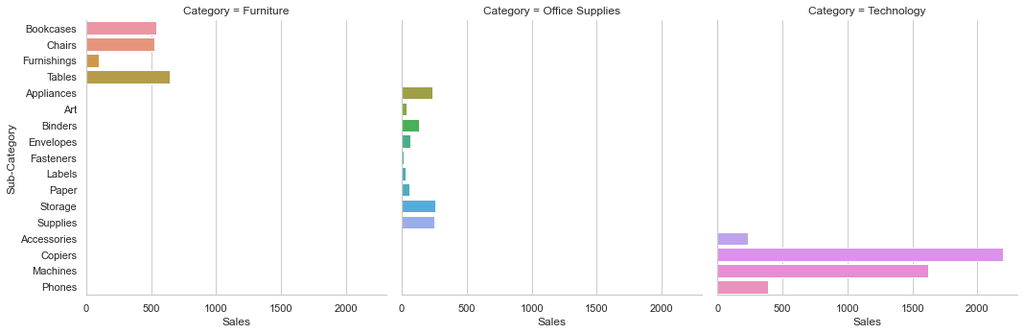

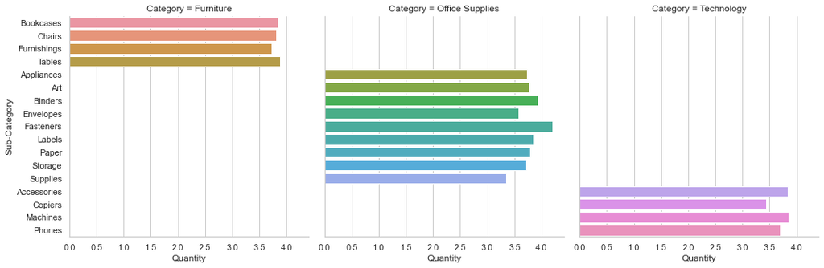

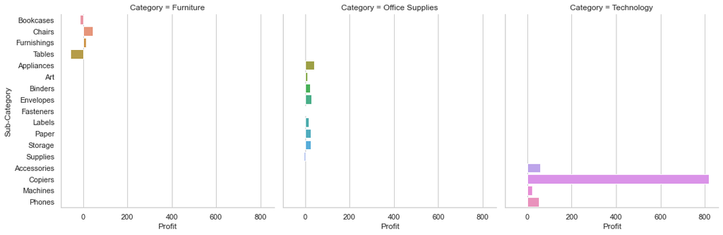

```python
x = sns.catplot(x="Sales", y="Sub-Category", col="Category", data=category_group, kind='bar')
y = sns.catplot(x="Quantity", y="Sub-Category", col="Category",data=category_group, kind='bar')
z = sns.catplot(x="Profit", y="Sub-Category", col="Category", data=category_group, kind='bar')
```

From these graphs, we can conclude that

- In technology category, Sales are clearly more than other two category.
- In technology category, Copiers and Machines are sold the most.
- Quantity of products are almost sold in equal amount in each category.
- In Furniture category, Bookcases and Tables are incurring a loss.
- In Office Supplies category, there is a very minimal profit in all sub-categories and Supplies is incurring a loss.
- In technology category, Copiers provide the most profit among all others.

### Segment-Wise:

```python
segment_group
```

|  | Segment | Sales | Quantity | Profit |
| --- | --- | --- | --- | --- |
| 0 | Consumer | 224.459894 | 3.758150 | 25.844228 |
| 1 | Corporate | 234.887815 | 3.843929 | 30.679042 |
| 2 | Home Office | 242.976554 | 3.787948 | 34.049117 |

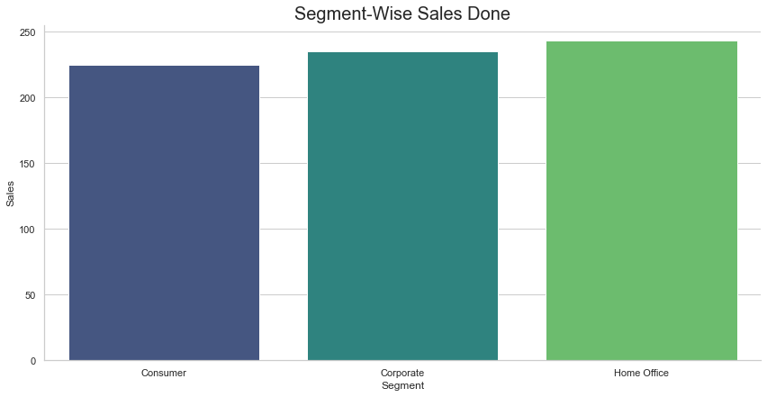

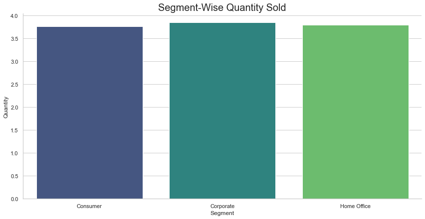

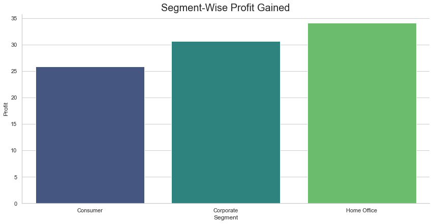

```python
x = sns.catplot(x="Segment", y="Sales", data=segment_group, kind='bar',height=6,aspect=2,palette='viridis')
plt.title("Segment-Wise Sales Done", fontsize=20)

y = sns.catplot(x="Segment", y="Quantity", data=segment_group, kind='bar',height=6,aspect=2,palette='viridis')
plt.title("Segment-Wise Quantity Sold", fontsize=20)

z = sns.catplot(x="Segment", y="Profit", data=segment_group, kind='bar',height=6,aspect=2,palette='viridis')
plt.title("Segment-Wise Profit Gained", fontsize=20)
plt.show()
```

From these graphs, we can conclude that

- All types of Segments have shown almost same number of sales.
- All types of Segments have shown almost same number of quantity sold.
- Profit gained in the Home Office segment is higher comparing other two segments with Consumer Segment being the lowest.

### Region-Wise

```python
region_group
```

|  | Region | Sales | Quantity | Profit |
| --- | --- | --- | --- | --- |
| 0 | Central | 216.019756 | 3.776652 | 16.917033 |
| 1 | East | 239.209221 | 3.731122 | 32.218506 |
| 2 | South | 244.466429 | 3.837940 | 29.235533 |
| 3 | West | 227.334897 | 3.826211 | 33.950393 |

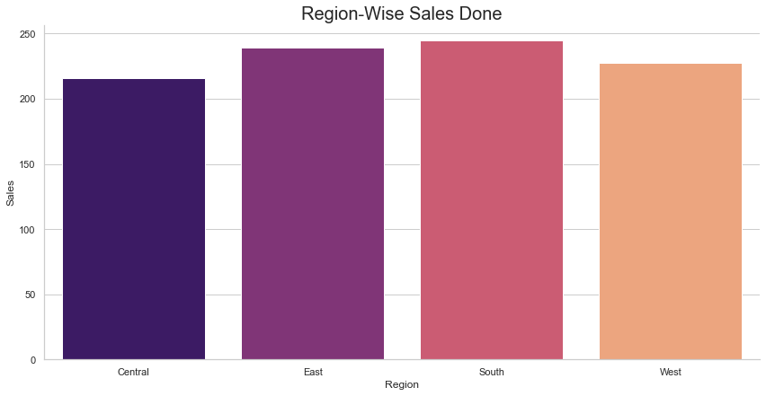

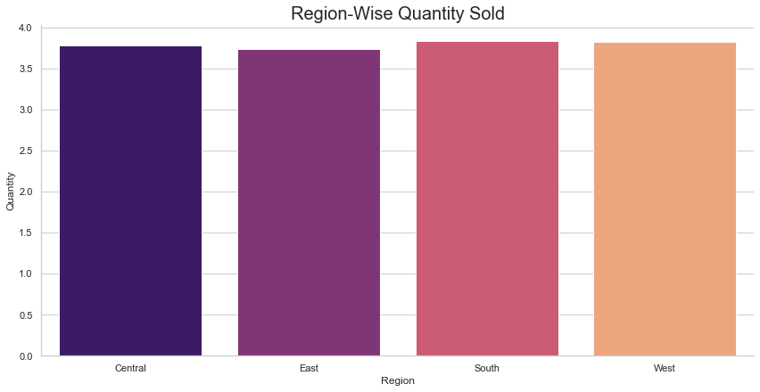

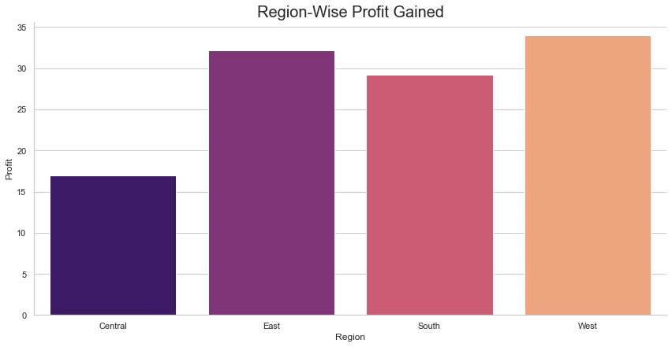

```python
a = sns.catplot(x='Region',y='Sales',data=region_group, kind='bar',height=6,aspect=2,palette='magma')
plt.title("Region-Wise Sales Done", fontsize=20)

b = sns.catplot(x='Region',y='Quantity',data=region_group, kind='bar',height=6,aspect=2,palette='magma')
plt.title("Region-Wise Quantity Sold", fontsize=20)

c = sns.catplot(x='Region',y='Profit',data=region_group,kind='bar',height=6,aspect=2,palette='magma')
plt.title("Region-Wise Profit Gained", fontsize=20)
plt.show()
```

From these graphs, we can conclude that

- Sales are more in Southern and Eastern part of US.
- Quantity of products sold in all the regions are almost same and not much of difference.
- Profit gained in Western part of US is comparatively higher followed by Eastern part, Southern part then Central part of US.

### State-Wise:

```python
state_group
```

|  | State | Sales | Quantity | Profit |
| --- | --- | --- | --- | --- |
| 0 | Alabama | 382.684783 | 4.652174 | 110.919896 |
| 1 | Arizona | 158.830592 | 3.880734 | -15.757166 |
| 2 | Arkansas | 172.982600 | 3.980000 | 53.142752 |
| 3 | California | 230.087185 | 3.824561 | 38.352592 |
| 4 | Colorado | 178.999290 | 3.816425 | -34.137260 |
| 5 | Connecticut | 135.448857 | 3.471429 | 37.334236 |
| 6 | Delaware | 279.529817 | 3.873016 | 87.944689 |
| 7 | District of Columbia | 286.502000 | 4.000000 | 105.958930 |
| 8 | Florida | 231.126005 | 3.629353 | -8.533003 |
| 9 | Georgia | 237.069257 | 3.873606 | 68.287411 |
| 10 | Idaho | 230.427647 | 3.058824 | 44.980712 |
| 11 | Illinois | 162.995301 | 3.715481 | -20.351664 |
| 12 | Indiana | 439.556145 | 3.915663 | 167.822957 |
| 13 | Iowa | 169.752500 | 4.250000 | 51.716667 |
| 14 | Kansas | 114.797826 | 3.130435 | 35.890657 |
| 15 | Kentucky | 257.475127 | 3.806061 | 77.312553 |
| 16 | Louisiana | 211.396588 | 3.666667 | 51.447333 |
| 17 | Maine | 232.890000 | 5.800000 | 84.444080 |
| 18 | Maryland | 213.831430 | 3.935484 | 62.959551 |
| 19 | Massachusetts | 203.656930 | 3.720930 | 56.284789 |
| 20 | Michigan | 287.730635 | 3.718978 | 91.098758 |
| 21 | Minnesota | 312.073685 | 3.747748 | 104.605003 |
| 22 | Mississippi | 234.183846 | 4.512821 | 64.440646 |
| 23 | Missouri | 277.823061 | 3.714286 | 60.425004 |
| 24 | Montana | 459.038182 | 4.272727 | 150.666300 |
| 25 | Nebraska | 196.445526 | 3.578947 | 53.607742 |
| 26 | Nevada | 406.418757 | 4.324324 | 80.930916 |
| 27 | New Hampshire | 177.619231 | 4.538462 | 63.606538 |
| 28 | New Jersey | 262.809430 | 3.633803 | 68.999687 |
| 29 | New Mexico | 111.515806 | 3.870968 | 32.425971 |
| 30 | New York | 277.372477 | 3.740707 | 65.646007 |
| 31 | North Carolina | 241.811166 | 3.959641 | -23.072835 |
| 32 | North Dakota | 131.415714 | 4.285714 | 32.878529 |
| 33 | Ohio | 171.811694 | 3.640227 | -46.362461 |
| 34 | Oklahoma | 298.233182 | 3.742424 | 73.544788 |
| 35 | Oregon | 130.003349 | 3.896226 | -0.437348 |
| 36 | Pennsylvania | 198.854178 | 3.669521 | -26.737736 |
| 37 | Rhode Island | 404.070643 | 3.553571 | 130.100523 |
| 38 | South Carolina | 253.899400 | 4.183333 | 64.767788 |
| 39 | South Dakota | 109.630000 | 3.500000 | 32.902358 |
| 40 | Tennessee | 162.996244 | 3.698718 | -33.304226 |
| 41 | Texas | 173.240043 | 3.778816 | -26.357700 |
| 42 | Utah | 222.132204 | 4.020408 | 49.949271 |
| 43 | Vermont | 636.150235 | 4.411765 | 95.299100 |
| 44 | Virginia | 309.045019 | 3.977444 | 67.135867 |
| 45 | Washington | 273.612451 | 3.725681 | 65.584244 |
| 46 | West Virginia | 304.238333 | 3.833333 | -20.431367 |
| 47 | Wisconsin | 281.896824 | 4.109244 | 62.348809 |
| 48 | Wyoming | 1603.136000 | 4.000000 | 100.196000 |

```python
sorted_sales = state_group.sort_values(['Sales'], ascending=False)[:10]
sorted_quantity = state_group.sort_values(['Quantity'], ascending=False)[:10]
sorted_profit = state_group.sort_values(['Profit'], ascending=False)[:10]
```

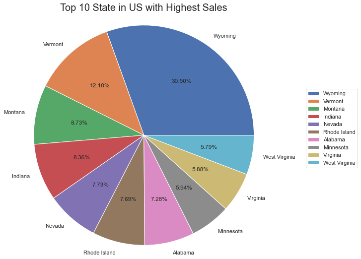

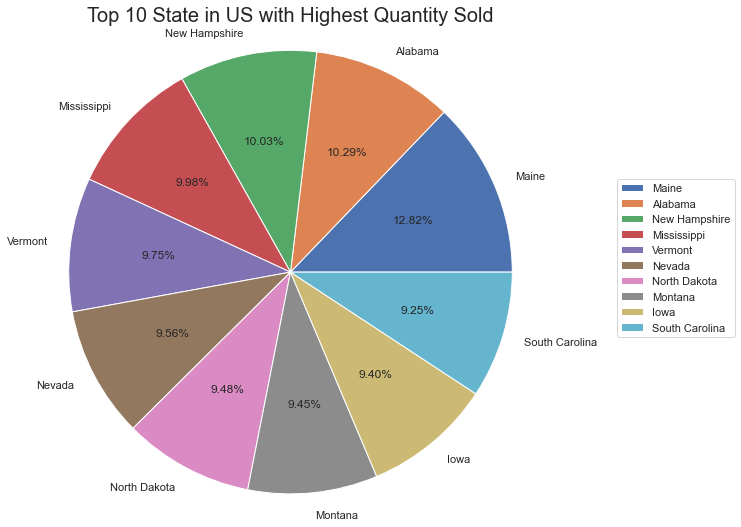

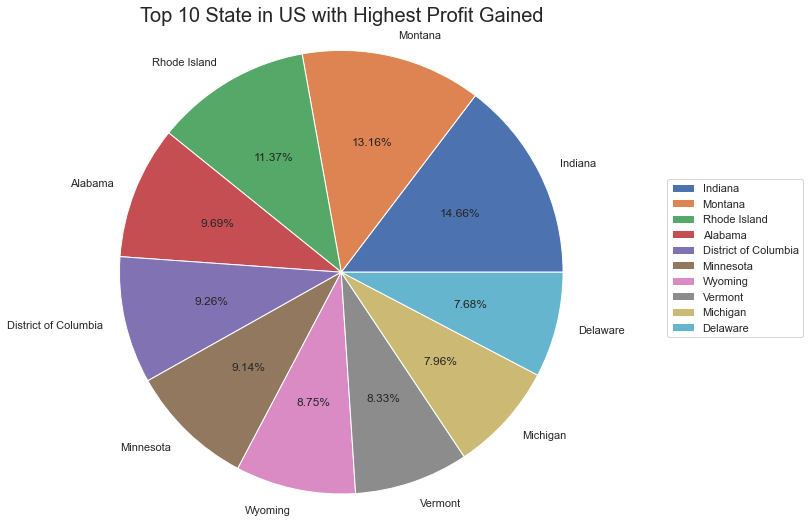

```python
sales_values = sorted_sales.Sales
quantity_values = sorted_quantity.Quantity
profit_values = sorted_profit.Profit

sales_labels = sorted_sales.State
quantity_labels = sorted_quantity.State
profit_labels = sorted_profit.State

plt.figure(figsize=(10,6))
plt.pie(sales_values, labels=sales_labels, autopct='%.2f%%',radius=1.7)
plt.legend(loc=(1.5,0.3))
plt.title("Top 10 State in US with Highest Sales", fontsize=20,y=1.25)
plt.show()

plt.figure(figsize=(10,6))
plt.pie(quantity_values, labels=quantity_labels, autopct='%.2f%%',radius=1.7)
plt.legend(loc=(1.5,0.3))
plt.title("Top 10 State in US with Highest Quantity Sold", fontsize=20,y=1.25)
plt.show()

plt.figure(figsize=(10,6))
plt.pie(profit_values, labels=profit_labels, autopct='%.2f%%',radius=1.7)
plt.legend(loc=(1.5,0.3))
plt.title("Top 10 State in US with Highest Profit Gained", fontsize=20,y=1.25)
plt.show()
```

From these graphs, we can conclude that

- Wyoming sales are highest among all but with a profit of only 8.75%.
- Almost all top 10 states have same quantity sold
- Indiana State gained the highest profit among all.

### Shipmode-Wise:

```python
shipmode_group
```

|  | Ship Mode | Sales | Quantity | Profit |
| --- | --- | --- | --- | --- |
| 0 | First Class | 231.435126 | 3.695162 | 32.218513 |
| 1 | Same Day | 236.140032 | 3.621974 | 28.864731 |
| 2 | Second Class | 237.688558 | 3.813905 | 29.713753 |
| 3 | Standard Class | 228.101129 | 3.820726 | 27.567955 |

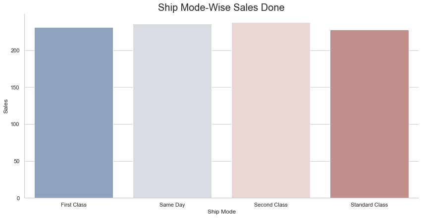

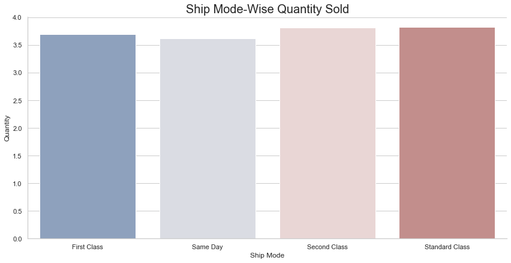

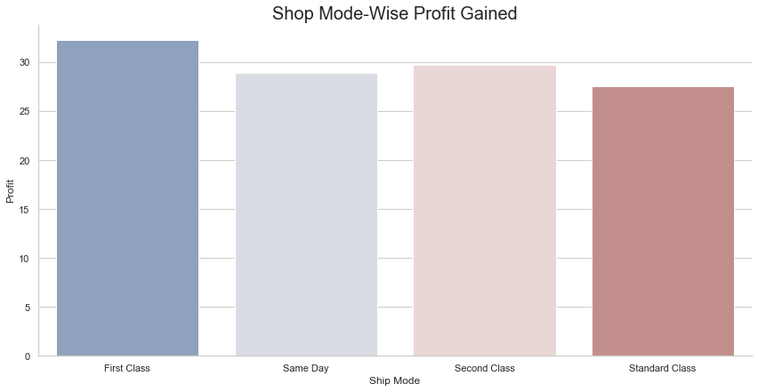

```python
x = sns.catplot(x="Ship Mode", y="Sales", data=shipmode_group, kind='bar',height=6,aspect=2,palette='vlag')
plt.title("Ship Mode-Wise Sales Done", fontsize=20)

y = sns.catplot(x="Ship Mode", y="Quantity", data=shipmode_group, kind='bar',height=6,aspect=2,palette='vlag')
plt.title("Ship Mode-Wise Quantity Sold", fontsize=20)

z = sns.catplot(x="Ship Mode", y="Profit", data=shipmode_group, kind='bar',height=6,aspect=2,palette='vlag')
plt.title("Shop Mode-Wise Profit Gained", fontsize=20)

plt.show()
```

From these graphs, we can conclude that ship mode doesn't affect the Profit, Sales and Quantity. All types of Ship Mode show almost same values.

### Month-Wise:

```python
orders["Month"] = orders["Order Date"].apply(lambda x: x.month)
monthDict={1:'Jan', 2:'Feb', 3:'Mar', 4:'Apr', 5:'May', 6:'Jun', 7:'Jul', 8:'Aug', 9:'Sep', 10:'Oct', 11:'Nov', 12:'Dec'}
orders['Month'] = orders['Month'].apply(lambda x: monthDict[x])
orders['Month']
```

```
0       Jan
1       Jan
2       Jan
3       Oct
4       Oct
       ...
9850    Jan
9851    Feb
9852    Feb
9853    Feb
9854    May
Name: Month, Length: 9855, dtype: object
```

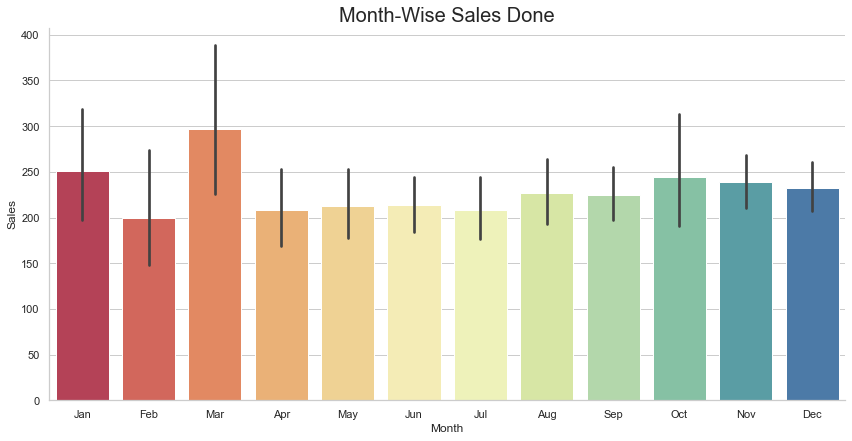

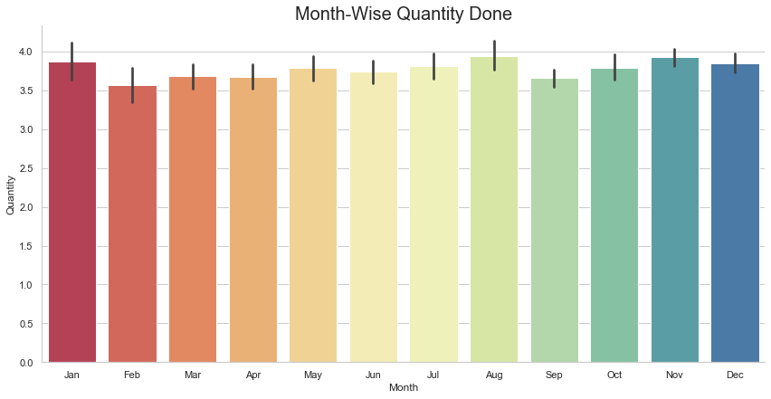

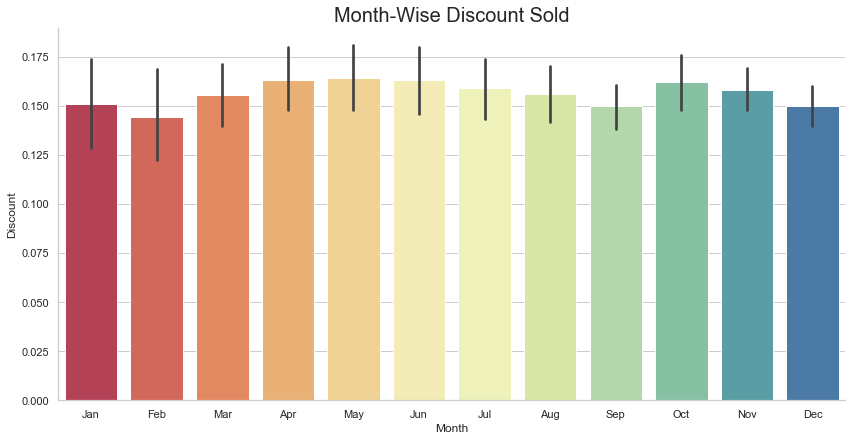

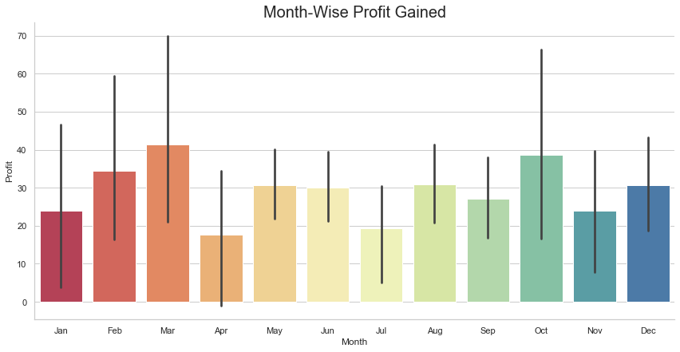

```python
Months = ['Jan', 'Feb', 'Mar', 'Apr', 'May', 'Jun', 'Jul', 'Aug', 'Sep', 'Oct', 'Nov', 'Dec']

sns.set(style='whitegrid')

a= sns.catplot(x="Month", y="Sales", data=orders,order=Months, kind='bar',height=6,aspect=2,palette='Spectral')
plt.title("Month-Wise Sales Done", fontsize=20)

x = sns.catplot(x="Month", y="Quantity", data=orders,order=Months, kind='bar',height=6,aspect=2,palette='Spectral')
plt.title("Month-Wise Quantity Done", fontsize=20)

y = sns.catplot(x="Month", y="Discount", data=orders,order=Months , kind='bar',height=6,aspect=2,palette='Spectral')
plt.title("Month-Wise Discount Sold", fontsize=20)

z = sns.catplot(x="Month", y="Profit", data=orders,order=Months, kind='bar',height=6,aspect=2,palette='Spectral')
plt.title("Month-Wise Profit Gained", fontsize=20)
plt.show()
```

March & October months should be paid more attention as it brings Maximum Profit.

### Heatmap to check correlation in Orders columns:

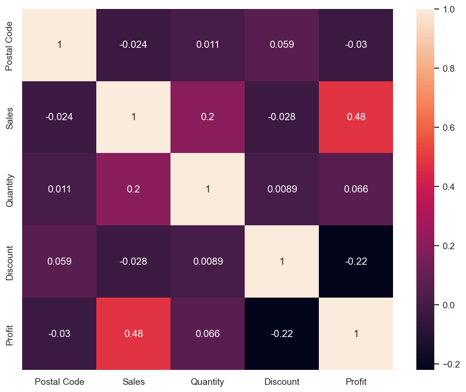

```python
plt.figure(figsize=(10,8),dpi=100)
sns.heatmap(orders.corr(), annot= True)
plt.show()
```

### Discount Vs Profit Graph:

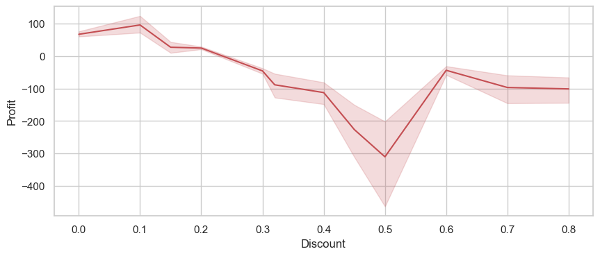

```python
plt.figure(figsize = (10,4),dpi=100)
sns.lineplot('Discount', 'Profit', data = orders,color='r')
plt.show()
```

### Sales Vs Profit Graph:

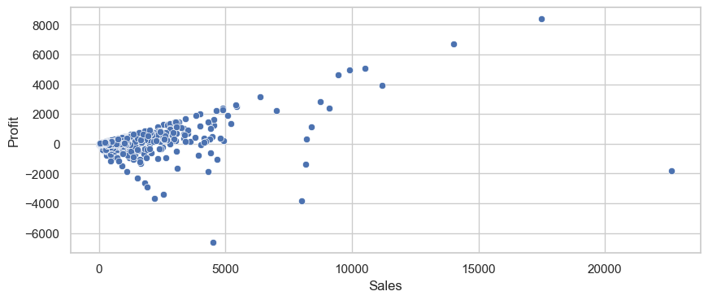

```python
plt.figure(figsize = (10,4),dpi=100)
sns.scatterplot('Sales', 'Profit', data = orders)
plt.show()
```

Increase in Sales mostly tend to bring more profit. We can find an outlier with maximum Sales Amount but incurring loss.

Finding more information about this **outlier**:

```python
orders[orders['Sales']==orders['Sales'].max()]
```

|  | Order ID | Order Date | Ship Date | Ship Mode | Customer ID | Country | City | State | Postal Code | Region | Product ID | Sales | Quantity | Discount | Profit | Month |
| --- | --- | --- | --- | --- | --- | --- | --- | --- | --- | --- | --- | --- | --- | --- | --- | --- |
| 2672 | CA-2014-145317 | 2014-03-18 | 2014-03-23 | Standard Class | SM-20320 | United States | Jacksonville | Florida | 32216 | South | TEC-MA-10002412 | 22638.48 | 6 | 0.5 | -1811.0784 | Mar |

This order had a 50% discount offered and as found in earlier plot, a 50% discount incurs maximum loss. So even with highest Sales , this order incurred a loss.

```python
customer[customer['Customer ID']=='SM-20320']
```

|  | Customer ID | Customer First Name | Customer Last Name | Segment |
| --- | --- | --- | --- | --- |
| 596 | SM-20320 | Sean | Miller | Home Office |

```python
returns[returns['Order ID']=='CA-2014-145317']
```

|  | Returned | Order ID |
| --- | --- | --- |

```python
products[products['Product ID']=='TEC-MA-10002412']
```

|  | Product ID | Category | Sub-Category | Product Name |
| --- | --- | --- | --- | --- |
| 1424 | TEC-MA-10002412 | Technology | Machines | Cisco TelePresence System EX90 Videoconferenci... |

Order is not returned and customer is from Home Office Segment which brings maximum profit. This outlier could be an exception. Machines from Technology doesn't bring enough profit.

## Creating Loss Dataframe:

```python
loss_orders=orders[orders['Profit'] < 0]
loss_orders.head()
```

|  | Order ID | Order Date | Ship Date | Ship Mode | Customer ID | Country | City | State | Postal Code | Region | Product ID | Sales | Quantity | Discount | Profit | Month |
| --- | --- | --- | --- | --- | --- | --- | --- | --- | --- | --- | --- | --- | --- | --- | --- | --- |
| 1 | CA-2015-146262 | 2015-01-02 | 2015-01-09 | Standard Class | VW-21775 | United States | Medina | Ohio | 44256 | East | FUR-BO-10004695 | 452.4500 | 5 | 0.50 | -244.3230 | Jan |
| 2 | CA-2015-146262 | 2015-01-02 | 2015-01-09 | Standard Class | VW-21775 | United States | Medina | Ohio | 44256 | East | TEC-PH-10002844 | 62.9820 | 3 | 0.40 | -14.6958 | Jan |
| 3 | US-2015-108966 | 2015-10-11 | 2015-10-18 | Standard Class | SO-20335 | United States | Fort Lauderdale | Florida | 33311 | South | FUR-TA-10000577 | 957.5775 | 5 | 0.45 | -383.0310 | Oct |
| 13 | CA-2015-146262 | 2015-01-02 | 2015-01-09 | Standard Class | VW-21775 | United States | Medina | Ohio | 44256 | East | TEC-MA-10000864 | 1188.0000 | 9 | 0.70 | -950.4000 | Jan |
| 14 | US-2015-118983 | 2015-11-22 | 2015-11-26 | Standard Class | HP-14815 | United States | Fort Worth | Texas | 76106 | Central | OFF-AP-10002311 | 68.8100 | 5 | 0.80 | -123.8580 | Nov |

```python
loss_orders.shape
```

```
(1851, 16)
```

Out of 9855 orders, 1851 have incurred loss.

```python
loss_orders.describe()
```

|  | Postal Code | Sales | Quantity | Discount | Profit |
| --- | --- | --- | --- | --- | --- |
| count | 1851.000000 | 1851.000000 | 1851.000000 | 1851.000000 | 1851.000000 |
| mean | 55920.120475 | 252.312939 | 3.764452 | 0.479708 | -83.750526 |
| std | 26085.153025 | 718.542285 | 2.144169 | 0.234812 | 285.681708 |
| min | 1841.000000 | 0.444000 | 1.000000 | 0.100000 | -6599.978000 |
| 25% | 33023.000000 | 12.606000 | 2.000000 | 0.200000 | -58.660950 |
| 50% | 60623.000000 | 71.372000 | 3.000000 | 0.400000 | -18.117600 |
| 75% | 77095.000000 | 287.156000 | 5.000000 | 0.700000 | -6.300900 |
| max | 98198.000000 | 22638.480000 | 14.000000 | 0.800000 | -0.089500 |

```python
loss_segment=segment_df[segment_df['Profit'] < 0].groupby(['Segment'])['Sales','Quantity','Discount','Profit'].sum().reset_index()
loss_segment
```

|  | Segment | Sales | Quantity | Discount | Profit |
| --- | --- | --- | --- | --- | --- |
| 0 | Consumer | 246584.5800 | 3616 | 469.26 | -84178.0663 |
| 1 | Corporate | 130866.8403 | 2165 | 268.70 | -44516.5432 |
| 2 | Home Office | 89579.8305 | 1187 | 149.98 | -26327.6133 |

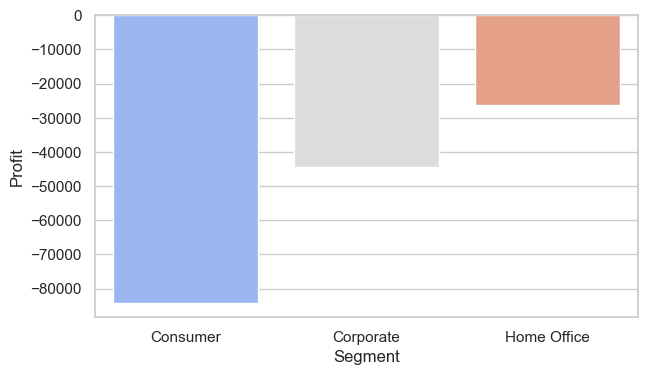

```python
plt.figure(figsize=(7,4),dpi=100)
sns.barplot(data=loss_segment,x='Segment',y='Profit',palette='coolwarm')
plt.show()
```

Consumer Segment incurred maximum loss.

We can also find that , more discount leads to more loss, so, to make more profit we need to provide fewer discounts.

```python
segment_df.sort_values(['Segment'],ascending=True).groupby('Segment').sum()
```

| Segment | Postal Code | Sales | Quantity | Discount | Profit |
| --- | --- | --- | --- | --- | --- |
| Consumer | 284689309 | 1.149908e+06 | 19253 | 809.41 | 132399.9812 |
| Corporate | 161472040 | 6.983215e+05 | 11428 | 469.75 | 91208.7918 |
| Home Office | 97155482 | 4.273958e+05 | 6663 | 260.73 | 59892.3975 |

```python
loss_subcategory=category_df[category_df['Profit'] < 0].groupby(['Sub-Category'])['Sales','Quantity','Discount','Profit'].sum().sort_values('Profit').reset_index()
loss_subcategory
```

|  | Sub-Category | Sales | Quantity | Discount | Profit |
| --- | --- | --- | --- | --- | --- |
| 0 | Binders | 36666.9810 | 2467 | 454.00 | -39232.0610 |
| 1 | Tables | 104978.5460 | 757 | 74.15 | -32412.1483 |
| 2 | Machines | 73985.3260 | 169 | 27.70 | -31626.3566 |
| 3 | Bookcases | 56456.9868 | 450 | 39.29 | -12369.2644 |
| 4 | Chairs | 92122.6490 | 894 | 63.10 | -9879.7319 |
| 5 | Appliances | 3381.1420 | 233 | 52.80 | -8625.8828 |
| 6 | Phones | 40213.6540 | 497 | 49.40 | -8431.7867 |
| 7 | Furnishings | 13109.8120 | 608 | 91.60 | -6670.8206 |
| 8 | Storage | 37991.2640 | 582 | 32.80 | -6396.7314 |
| 9 | Supplies | 14049.5920 | 103 | 6.40 | -3011.4457 |
| 10 | Accessories | 12952.3120 | 347 | 19.20 | -1000.4203 |
| 11 | Fasteners | 149.2800 | 55 | 2.40 | -33.1952 |

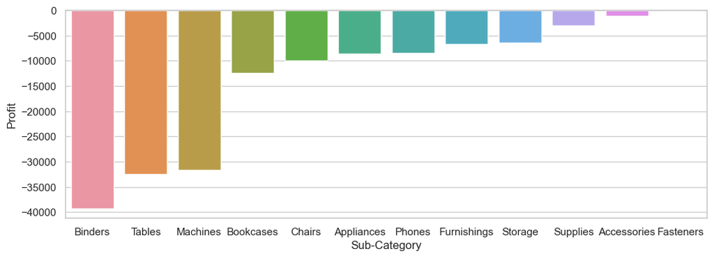

```python
plt.figure(figsize=(12,4),dpi=100)
sns.barplot(data=loss_subcategory,x='Sub-Category',y='Profit')
plt.show()
```

- We can observe more loss in the Binders category, tables category, and machines category when compared to other categories.
- Binders are more getting sold. So even giving less discount may lead to vast loss. So better to give discounts on which are getting less sold so that even they will start getting sold more.

```python
loss_category=category_df[category_df['Profit'] < 0].groupby(['Category'])['Sales','Quantity','Discount','Profit'].mean().sort_values('Profit').reset_index()
loss_category
```

|  | Category | Sales | Quantity | Discount | Profit |
| --- | --- | --- | --- | --- | --- |
| 0 | Technology | 444.584937 | 3.541958 | 0.336713 | -143.561411 |
| 1 | Furniture | 364.300538 | 3.700820 | 0.366311 | -83.786838 |
| 2 | Office Supplies | 103.755072 | 3.869516 | 0.616873 | -64.453674 |

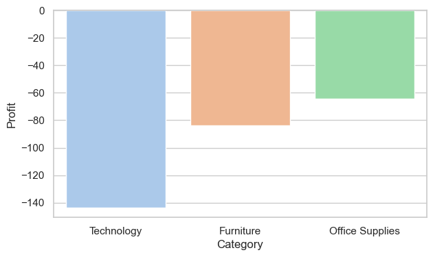

```python
plt.figure(figsize=(7,4),dpi=100)
sns.barplot(data=loss_category,x='Category',y='Profit',palette='pastel')
plt.show()
```

On an average, we observed that more loss is in the technology category.

```python
loss_orders.groupby(['Region'])['Sales','Quantity','Discount','Profit'].sum().reset_index()
```

|  | Region | Sales | Quantity | Discount | Profit |
| --- | --- | --- | --- | --- | --- |
| 0 | Central | 140733.0728 | 2760 | 400.34 | -55507.0183 |
| 1 | East | 160860.3640 | 1986 | 246.40 | -49587.8107 |
| 2 | South | 91431.5870 | 991 | 123.85 | -27355.4989 |
| 3 | West | 74006.2270 | 1231 | 117.35 | -22571.8949 |

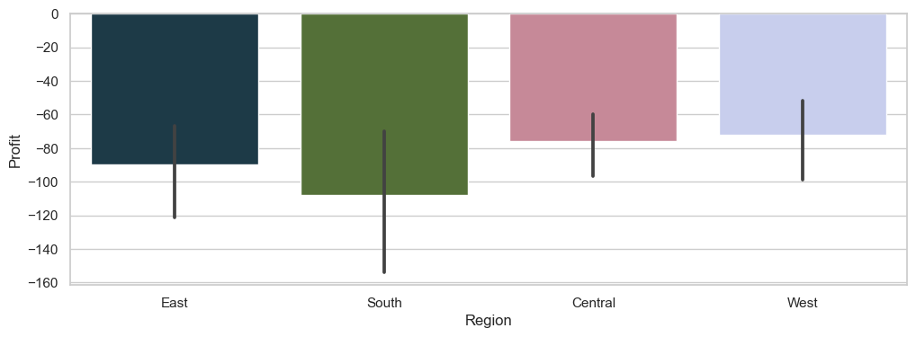

```python
plt.figure(figsize=(12,4),dpi=100)
sns.barplot(data=loss_orders,x='Region',y='Profit',palette='cubehelix')
plt.show()
```

Even with least discount and sales in the West Region, it has incurred minimum total loss compared to other regions. So, to get better profits or more sales we should focus on this region.

Central region with high sales and maximum loss has highest discounts, so this Region should be provided less discounts for reducing loss.

## Analysing Orders Count:

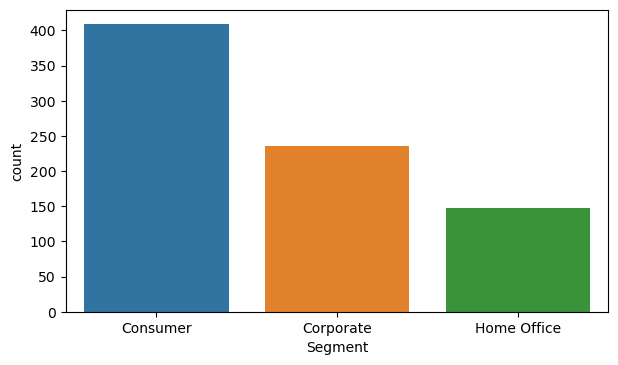

```python
plt.figure(figsize=(7,4),dpi=100)
sns.countplot(x=customer.Segment)
plt.show()
```

In the Home Office Segment, we observe that the count is less and as visualised in above plot, this segment brings maximum profit. So improvement is a necessity for this Segment.

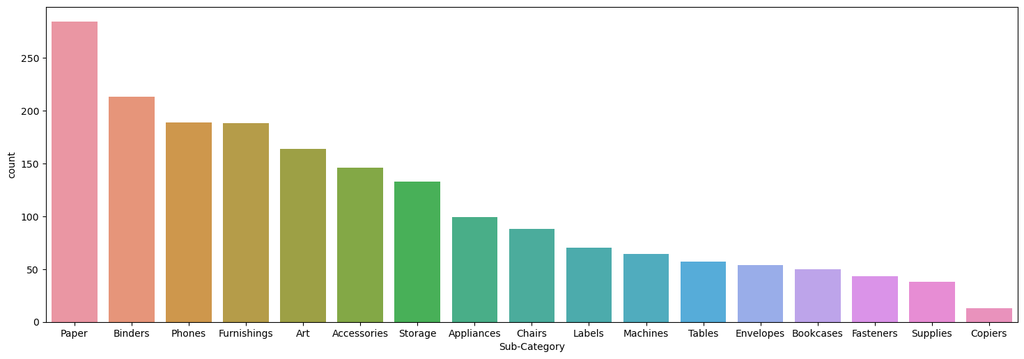

```python
plt.figure(figsize=(18,6),dpi=100)
sns.countplot(x='Sub-Category',data=products,order=products['Sub-Category'].value_counts().index)
plt.show()
```

From the above data, it’s very much clear that the Copiers Subcategory needs improvement. Copiers is also found to be the sub-category yielding maximum profits to the superstore.

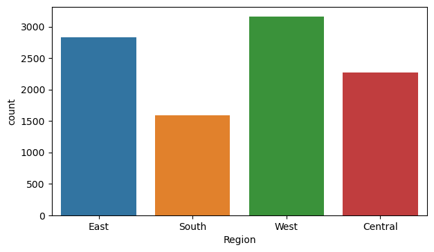

```python
plt.figure(figsize=(7,4),dpi=100)
sns.countplot(x='Region',data=orders)
plt.show()
```

From the data region-wise, we can conclude that the south region needs more improvement compared to others.

# Overall Analysis:

- The main reason which leads to loss is Discount as some areas lead to loss due to more discounts, and some areas lead to fewer sales due to fewer discounts, hence it needs to be improved.
- It is better to give more discounts during festival seasons, additionally, that will result in more sales.
- Few states have fewer sales, lack of awareness can be the reason for this, hence advertising in those states might help in more sales.
- Technology Category are in demand. So if production in this field will be more, then company can get more profit.
- Profit gain is highest in Home-Office segment. Company must emphasise more to Home-Office segment.
- People in the South and East prefer most of the goods. Company must spread out their products in these part of US.
- Profit are highest in Western part of US. Company should produce more in this part of US but must come with a plan to increase the sales.
- Wyoming State have highest sales and Indiana State have the highest Profit. Company must place all types of products in these states for more profit and sales.